# STSCI 4060 - Lecture 09

Creating Dynamic Web Pages with Python

Harry Lu

# 1 Different Types of Documents Involved

- **Python files**
  - **Files with .py extension:** Regular Python programs to take input and produce output for displaying on a web page.
  - **Files with .cgi extension:** Python CGI (Common Gateway Interface) programs to be run from a web server. To run a CGI program for our situation, you must start at `http://localhost:8081/`, followed with the **file name**. This file must be in the same folder as the local server program, `localCGIServer.py`.
- **HTML files**
  - **Template files and Output files:** They are used by Python programs internally to create a template or format string to dynamically generate the final web pages.
  - **Files for web browser display:** These files all have a **.html** extension and should be stored in the same folder as the `localCGIServer.py` (which should be running all the time-run from the folder directly). In the browser URL field, the web page file must be preceded by `http://localhost:8081/`, e.g., `http://localhost:8081/mypage.html`.

# 2 Create Local Pages with Python

## 2.1 Version 1: `helloWeb1.py`

The web page content is hard-coded in the program.

```python
'''A simple program to create an html file from a given string, and call the default web browser to display the file.'''

contents = '''<!DOCTYPE html PUBLIC "-//W3C//DTD HTML 4.01 Transitional//EN">
<html>
<head>
  <meta content="text/html; charset=ISO-8859-1" http-equiv="content-type">
  <title>Hello 1</title>
</head>
<body>
Hello, World!
</body>
</html>
'''

def main():
    browseLocal(contents, "helloPython1.html")

def strToFile(text, filename):
    '''Write a file with the given name and the given text.'''
    output = file(filename, "w")
    output.write(text)
    output.close()

def browseLocal(webpageText, filename):
    '''Start your webbrowser on a local file containing the text.'''
    strToFile(webpageText, filename)
    import webbrowser
    webbrowser.open(filename)

main()
```

## 2.2 Version 2: `helloWeb2.py`

The web page content is hard-coded in the program but a formatted string is used.

```python
'''Create an html file with user input (a name) embedded, and call the default web browser to display the file.'''

# NEW more appropriate name, now that it is a format string
pageTemplate = '''
<!DOCTYPE html PUBLIC "-//W3C//DTD HTML 4.01 Transitional//EN">
<html>
<head>
  <meta content="text/html; charset=ISO-8859-1" http-equiv="content-type">
  <title>Hello 2</title>
</head>
<body>
Hello, %s!
</body>
</html>
''' # NEW note '%s' two lines up

def main(): # NEW
    person = raw_input("Enter a name: ")
    contents = pageTemplate % person
    browseLocal(contents, "helloPython2.html")

def strToFile(text, filename):
    '''Write a file with the given name and the given text.'''
    output = file(filename, "w")
    output.write(text)
    output.close()

def browseLocal(webpageText, filename):
    '''Start your webbrowser on a local file containing the text.'''
    strToFile(webpageText, filename)
    import webbrowser
    webbrowser.open(filename)

main()
```

## 2.3 Version 3: `helloWeb3.py`

The web page content is based on a template and user input.

```python
'''Prompt the user for a name, and display a web page including the name, taking the web page template from a file.'''

def fileToStr(fileName): # NEW
    '''Return a string containing the contents of the named file.'''
    templateFile = open(fileName);
    contents = templateFile.read();
    templateFile.close()
    return contents

def makePage(templateFileName, substitutions): # NEW
    '''Returns a string with substitutions into a format string taken from the named file. The parameter substitutions must be in a format usable in the format operation: a single data item, a dictionary, or a tuple.'''
    pageTemplate = fileToStr(templateFileName)
    return pageTemplate % substitutions

def main():
    person = raw_input("Enter a name: ")
    contents = makePage("helloTemplate.html", person) # NEW
    browseLocal(contents, "helloPython3.html") # NEW filename

def strToFile(text, filename):
    '''Write a file with the given name and the given text.'''
    output = file(filename, "w")
    output.write(text)
    output.close()

def browseLocal(webpageText, filename):
    '''Start your webbrowser on a local file containing the text.'''
    strToFile(webpageText, filename)
    import webbrowser
    webbrowser.open(filename)

main()
```

# 3 Create a Web Page Calculating Simple Statistics of a List of Numbers with Python

```python
'''Prompt the user for a list of numbers and display a web page with simple statistics.'''
import scipy as sp

def processInput(theList): # NEW
    '''Process input parameters and return the final page as a string.'''
    theSum = sum(theList) # transform input to output data
    theMean = sp.mean(theList)
    theCount = len(theList)
    theSTD = sp.std(theList)
    theMedian = sp.median(theList)
    theMin = min(theList)
    theMax = max(theList)
    return makePage("statTemplate.html", (theList, theCount, theSum, theMean, theMedian, theSTD, theMin, theMax))

def main(): # NEW
    theList = input("Enter a list of numbers: ") # obtain input
    contents = processInput(theList) # process input into a page
    browseLocal(contents, "helloPython4.html") # display page

def fileToStr(fileName):
    '''Return a string containing the contents of the named file.'''
    fin = open(fileName);
    contents = fin.read();
    fin.close()
    return contents

def makePage(templateFileName, substitutions):
    pageTemplate = fileToStr(templateFileName)
    return pageTemplate % substitutions

def strToFile(text, filename):
    output = file(filename, "w")
    output.write(text)
    output.close()

def browseLocal(webpageText, filename):
    strToFile(webpageText, filename)
    import webbrowser
    webbrowser.open(filename)

main()
```

# 4 Create Dynamic Web Pages with Python

- **CGI (common gateway interface)** is an interface used by web servers to process information requests supplied by a browser. All the server programs end in a “**.cgi**” extension, which are all Python programs in our case; these programs are often called scripts, or **Python CGI scripts**.
  - Download the `localCGIServer.py` file from the course web site (within the “Software” folder)
  - Save this file to the folder where you store all your web page files.
  - Make sure there are **no spaces (or blanks)** in different levels of directory names.
  - Start your local web server by double clicking on `localCGIServer.py` (in Windows OS do not start from within IDEL, etc.) and keep it running by leaving the console window open.
  - Input a local link to your html file, e.g., `http://localhost:8081/hello.html`, in your browser’s URL window.
  - Now the web address is your localhost:8081, which references the local Python server we just started.
  - Look at the web server console window, where you should see some activity.
  - If you close the console window, you get an error when you try to reload the page.

# 5 Create a Dynamic Local Web Page for Calculating Simple Statistics of a List of Numbers with Python

## 5.1 Set form/field properties and link the web page to a Python CGI script

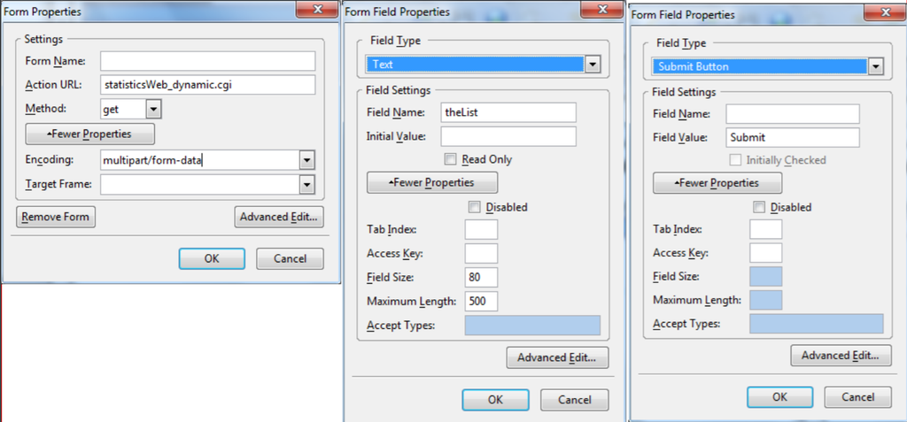

1. Container Form [Form Properties]
   - Settings
     - Form Name: N/A
     - **Action URL:** statisticsWeb_dynamic.cgi
     - **Method:** get
     - **Encoding:** multipart/form-data
     - Target Frame: N/A
2. Input Box [Form Field Properties]
   - Field Type
     - **Text**
   - Field Settings
     - **Field Name:** theList
     - Initial Value: N/A
     - Tab Index: N/A
     - Access Key: N/A
     - **Field Size:** 80
     - **Maximum Length:** 500
     - Accept Types: N/A
3. Submit Button [Form Field Properties]
   - Field Type
     - **Submit Button**
   - Field Settings
     - Field Name: N/A
     - **Field Value:** Submit
     - Tab Index: N/A
     - Access Key: N/A
     - Field Size: N/A
     - Maximum Length: N/A
     - Accept Types: N/A

## 5.2 Python CGI script file(s)

```python
#!/usr/bin/env python

'''Promp the user for a list of numbers and display a web page with simple statistics.'''
import scipy as sp
import cgi

def main(): # NEW
    form = cgi.FieldStorage() # cgi script line
    theStr = form.getfirst("theList","")
    theList = theStr.split()
    num = range(len(theList))
    for i in num:
        theList[i] = float(theList[i])
    contents = processInput(theList) # process input into a page
    print contents

def processInput(theList):
    '''Process input parameters and return the final page as a string.'''
    theSum = sum(theList) # transform input to output data
    theMean = sp.mean(theList)
    theCount = len(theList)
    theSTD = sp.std(theList)
    theMedian = sp.median(theList)
    theMin = min(theList)
    theMax = max(theList)
    return makePage("statTemplate.html", (theList, theCount, theSum, theMean, theMedian, theSTD, theMin, theMax))

def fileToStr(fileName):
    '''Return a string containing the contents of the named file.'''
    fin = open(fileName);
    contents = fin.read();
    fin.close()
    return contents

def makePage(templateFileName, substitutions):
    pageTemplate = fileToStr(templateFileName)
    return pageTemplate % substitutions

def strToFile(text, filename):
    output = file(filename, "w")
    output.write(text)
    output.close()

def browseLocal(webpageText, filename):
    strToFile(webpageText, filename)
    import webbrowser
    webbrowser.open(filename)

try:
    print "Content-type: text/html\n\n"
    main()
except:
    cgi.print_exception()
```